# Data 602 - Assignment One

## A Brief Tutorial on Bar Graphs

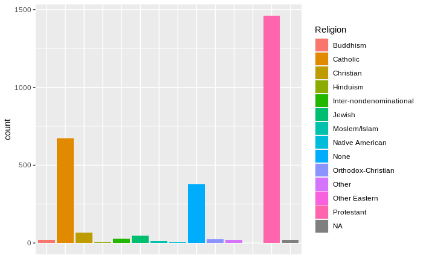

```r
ggplot(data=gss, aes(x = Religion, fill=Religion)) + geom_bar(position="dodge", na.rm=TRUE) + theme(axis.title.x=element_blank(),
        axis.text.x=element_blank(),
        axis.ticks.x=element_blank())
```

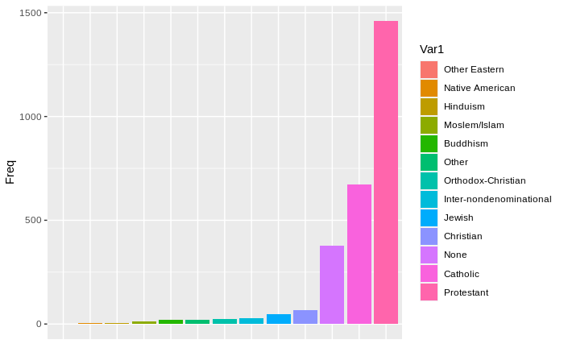

```r
counts = as.data.frame(sort(table(gss$Religion)))
# head(counts, 4)
ggplot(data=counts, aes(x=Var1, y=Freq, fill=Var1)) + geom_bar(stat="identity") + theme(axis.title.x=element_blank(),
        axis.text.x=element_blank(),
        axis.ticks.x=element_blank())
```

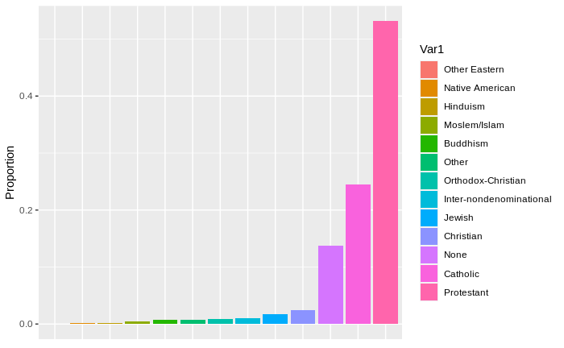

```r
reliprop = counts$Freq/sum(counts$Freq) #converts counts to proportions
counts1 = data.frame(counts, reliprop) #create a new data frame adding reliprob variable to counts
# head(counts1, 4)
ggplot(data=counts1, aes(x=Var1, y=reliprop, fill=Var1)) + geom_bar(stat="identity") + ylab("Proportion") + theme(axis.title.x=element_blank(),
        axis.text.x=element_blank(),
        axis.ticks.x=element_blank())
```

Another type of bar graph shows a distribution of responses for a certain level of a categorical variable. Consider the bar graph below, which was produced with the code:

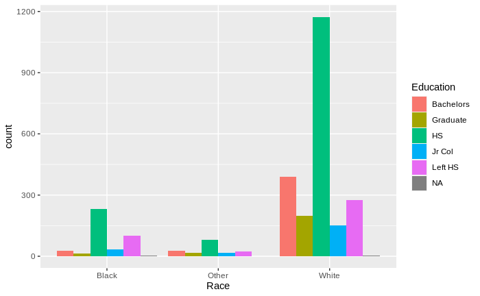

```r
ggplot(data=gss, aes(x = Race, fill=Education)) + geom_bar(position = "dodge", na.rm=TRUE)
```

From above one can see the distribution of education level amongst the three different types of races data was collected on in the 2002 General Social Survey.

We can also parse out the data and look at bargraph for a certain race:

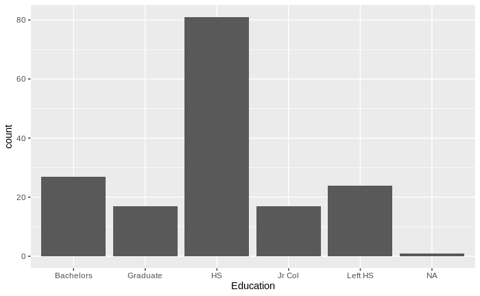

```r
ggplot(data=filter(gss, Race == "Other"), aes(x = Education)) + geom_bar(na.rm=TRUE)
```

This can be converted into a sorted type of bar graph with

```r
newdat = filter(gss, Race == "Other")
counts = as.data.frame(sort(table(newdat$Education)))
counts
```

| Var1 | Freq |
| --- | --- |
| Graduate | 17 |
| Jr Col | 17 |
| Left HS | 24 |
| Bachelors | 27 |
| HS | 81 |

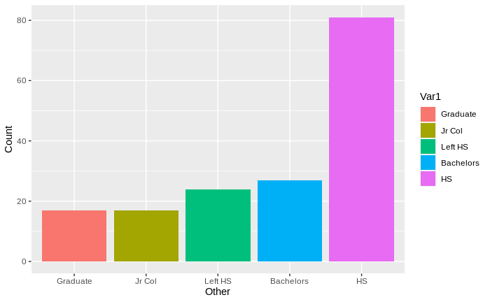

```r
ggplot(data=counts, aes(x=Var1, y=Freq, fill=Var1)) + geom_bar(stat="identity") + xlab("Other") + ylab("Count")
```

```r
props = counts$Freq/sum(counts$Freq)
props
```

```
[1] 0.1024096 0.1024096 0.1445783 0.1626506 0.4879518
```

```r
newdat2 = data.frame(counts, props)
head(newdat2, 5)
```

|  | Var1 | Freq | props |
| --- | --- | --- | --- |
| 1 | Graduate | 17 | 0.1024096 |
| 2 | Jr Col | 17 | 0.1024096 |
| 3 | Left HS | 24 | 0.1445783 |
| 4 | Bachelors | 27 | 0.1626506 |
| 5 | HS | 81 | 0.4879518 |